# Markov Chains

The state vector in Markov chain dynamical systems models *probabilities* or *proportions*. For example, we may have a 4-state vector describing the probability of the weather being either sunny, rainy, cloudy, or foggy. We may have a 50-vector modeling the proportion of the US population living in each state. Naturally, the components of these vectors, also called *distributions*, must always sum to 1.

A **Markov chain** is a model describing how these state vectors change over time according to a *Markov* or *stochastic matrix* $A$. For example, $A$ may describe the inflows and outflows of the US state populations, or the probabilities of the weather changing from one condition to another. The values of $A$ must be nonnegative, and each column must sum to 1. For example, if we have two states A and B,

$$\mathbf u_{k+1} = \begin{bmatrix} 0.8&0.3 \\ 0.2&0.7 \end{bmatrix} \mathbf u_k$$

says that 80% of A goes to A and 30% of B goes to A. The remaining 20% of A goes to B and the remaining 70% of B goes to B.

Since the components of $\mathbf u_k$ are nonnegative and always sum to 1, Markov chains are stable systems. All eigenvalues have magnitude less than or equal to 1. In addition, *all* Markov matrices have an eigenvalue equal to 1. To see this, consider $A - \lambda I = A-I$. Since each column of $A$ sums to 1, each column of $A$ sums to 0. But this tells us that the rows of $A-I$ must be linearly dependent. Hence $|A - \lambda I| = 0$ and $\lambda=1$ must be an eigenvalue.

## Stationary Distributions

Recall that the solution to a dynamical system is given by

$$\mathbf u_k = c_1 \lambda_1^k \mathbf x_1 + \cdots + c_n \lambda_n^k \mathbf x_n.$$

Let $\lambda_1=1$ (and all other $\lambda_i$ will have magnitude less than or equal to 1). The eigenvector $\mathbf x_1$, upon rescaling such that all components sum to 1, is called a **stationary distribution** of the Markov chain. Given $\mathbf u_0 = \mathbf x_1$, we have that $c_1=1$ and all other $c_i=0$. So we find that $\mathbf u_k = c_1 \lambda_1^k \mathbf x_1 = \mathbf x_1$ for all $k$; the state vector stays the same for all time.

## Steady States

Now suppose $\mathbf u_0 \neq \mathbf x_1$; we start with a distribution that is different from the stationary one. $\mathbf c$ will express the coordinates of $\mathbf u_0$ in the eigenvector basis, and it will no longer look like $\mathbf e_1$. But consider what $\mathbf u_k$ looks like as $k \rightarrow \infty$. If all eigenvalues other than $\lambda_1$ have magnitude less than 1, then

$$\mathbf u_k \rightarrow c_1 \lambda_1^k \mathbf x_1 = c_1 \mathbf x_1.$$

We have not computed $c_1$ as we have not specified $\mathbf u_0$. However, we know that $\mathbf u_k$ must be a valid distribution (all components sum to 1). So in this scenario, $\mathbf u_k$ approaches the stationary distribution $\mathbf x_1$, which can also be called a **steady state** of the Markov chain.

A Markov chain may have multiple stationary distributions if there is more than one linearly independent eigenvector corresponding to $\lambda=1$. Any of these may be a possible steady state depending on the initial distribution $\mathbf u_0$. Further, if $-1$ is also an eigenvalue, then there may be no steady state at all, since $(-1)^k$ does not decay as $k \rightarrow \infty$.

```python
import numpy as np
import matplotlib.pyplot as plt
```

```
L =  [0.75 1.  ]
X =
 [[-0.70710678 -0.24253563]
 [ 0.70710678 -0.9701425 ]]
stationary distribution:  [0.2 0.8]
```

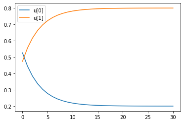

```python
# Citibikes (rental cars)
# uk = (pA, pB): proportion (probability) in state A/B

A = np.array([[.8,.05],
              [.2,.95]])
L, X = np.linalg.eig(A)
print("L = ", L)
print("X = \n", X)
print("stationary distribution: ", X[:,1]/np.sum(X[:,1]))

k = 30
u = np.zeros((k+1,2))
u[0,:] = np.random.random(2)
u[0,:] /= np.sum(u[0,:])
for i in range(k):
  u[i+1,:] = A @ u[i,:]

plt.plot(u)
plt.legend(['u[0]', 'u[1]'])
plt.show()
```

```
[ 1.          1.         -1.          0.          0.40824829 -0.40824829]
[[ 1.          0.          0.        ]
 [ 0.          0.70710678 -0.70710678]
 [ 0.          0.70710678  0.70710678]
 [ 0.          0.          0.        ]
 [ 0.          0.          0.        ]
 [ 0.          0.          0.        ]]
```

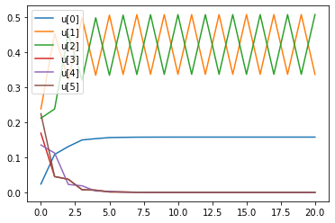

```python
# Multiple stationary distributions
A = np.array([[1,0,0,.5,0,0],
              [0,0,1,.5,1/3,.5],
              [0,1,0,0,0,0],
              [0,0,0,0,1/3,0],
              [0,0,0,0,0,.5],
              [0,0,0,0,1/3,0]])

# A has two repeated eigenvalues equal to 1
# Any combination of corresponding eigenvectors is stationary
L, X = np.linalg.eig(A)
print(L)
print(X[:,0:3])

u0 = np.random.random(6)
u0 /= np.sum(u0)

k = 20
u = np.zeros((k+1,6))
u[0,:] = np.random.random(6)
u[0,:] /= np.sum(u[0,:])
for i in range(k):
  u[i+1,:] = A @ u[i,:]

plt.plot(u)
plt.legend(['u[0]', 'u[1]', 'u[2]', 'u[3]', 'u[4]', 'u[5]'])
plt.show()
```

## PageRank

PageRank was developed by Google cofounders Larry Page and Sergey Brin at Stanford University in 1996. It is an algorithm used to *rank* web pages in search engine results by their importance. While there are many ways to define and tweak this metric, the fundamental idea is that more important websites have more incoming links from other websites. We can represent these relationships using a graph, where webpages are nodes and links are directed edges.

[figure not shown]

[credit: [Wikipedia](https://en.wikipedia.org/wiki/PageRank)]

We treat the set of webpages as states of a Markov chain. $n$ webpages means that we have a $n$-dimensional state vector. We can construct the $n \times n$ transition matrix $A$ by denoting $a_{ij}$ to be the *proportion* of links on page $j$ going to page $i$. As long as every webpage has at least one outgoing link, every column is nonnegative and sums to 1. $A$ is thus a Markov matrix, and we can find the stationary distribution in order to rank the webpages from most relevant to least relevant.

### Adjustments

There are a few potential issues with defining $A$ as described above. First, there may be webpages with no outgoing links (e.g., static documents or images). These are called **sinks** and correspond to zero columns in $A$. One solution is to pretend that there is an edge from a sink to every other webpage; in other words, a user may simply *teleport* to a webpage at random by navigating to the URL bar. This replaces the zero column in $A$ with a column of $\frac1n$ values.

Teleportation doesn't only occur at sinks; users may navigate to non-linked webpages at any time. Thus, a further adjustment to the PageRank transition matrix matrix is to add a constant term to every matrix component. If $A$ is the original transition matrix, the **Google matrix** is defined as

$$G = d A + (1-d) \frac1n \mathbf 1 \mathbf 1^\top$$

$d$ is a *damping factor* between 0 and 1, and the second term is a constant matrix with every term equal to $\frac{1-d}n$. The above form ensures that $G$ is still a valid Markov matrix. For example, if we take $d=0.85$, this means that a user will jump to another webpage (e.g., via URL) $15\%$ of the time.

### Computation of PageRank

Given the definition above, it can be proven that $G$ has a unique stationary distribution $\pi$. So the problem is to solve for $\pi$, and then rank each webpage according to its value in $\pi$. We know that we can do this by solving for the eigenvector of $G$ corresponding to $\lambda=1$. The alternative method of repeated matrix multiplication $G^k \mathbf u_0$ (for an arbitrary initial state vector $\mathbf u_0$) may actually be more viable in most applications, as $G$'s size actually makes solving for eigenvectors a more computationally intensive task.

Take the example in the graphic above. There are 11 webpages in total. Treating them in alphabetical order, and ordering the unlabeled purple nodes from left to right as the last 5 state components, we obtain the following transition matrix:

```python
A = np.array([[0,0,0,.5,0,0,0,0,0,0,0],
              [0,0,1,.5,1/3,.5,.5,.5,.5,0,0],
              [0,1,0,0,0,0,0,0,0,0,0],
              [0,0,0,0,1/3,0,0,0,0,0,0],
              [0,0,0,0,0,.5,.5,.5,.5,1,1],
              [0,0,0,0,1/3,0,0,0,0,0,0]])
A = np.vstack((A,np.zeros((5,11))))
print(A)
```

```
[[0.         0.         0.         0.5        0.         0.
  0.         0.         0.         0.         0.        ]
 [0.         0.         1.         0.5        0.33333333 0.5
  0.5        0.5        0.5        0.         0.        ]
 [0.         1.         0.         0.         0.         0.
  0.         0.         0.         0.         0.        ]
 [0.         0.         0.         0.         0.33333333 0.
  0.         0.         0.         0.         0.        ]
 [0.         0.         0.         0.         0.         0.5
  0.5        0.5        0.5        1.         1.        ]
 [0.         0.         0.         0.         0.33333333 0.
  0.         0.         0.         0.         0.        ]
 [0.         0.         0.         0.         0.         0.
  0.         0.         0.         0.         0.        ]
 [0.         0.         0.         0.         0.         0.
  0.         0.         0.         0.         0.        ]
 [0.         0.         0.         0.         0.         0.
  0.         0.         0.         0.         0.        ]
 [0.         0.         0.         0.         0.         0.
  0.         0.         0.         0.         0.        ]
 [0.         0.         0.         0.         0.         0.
  0.         0.         0.         0.         0.        ]]
```

Note the first column of all zeros due to the fact that node A has no outgoing links. This makes $A$ an invalid Markov matrix, so we replace the column with all values equal to $\frac1{11}$. Lastly, we need to add damping. Suppose we use $d=0.85$, giving us the final Google matrix:

```python
G = A
G[:,0] = 1/11
G = 0.85*G + .15/11*np.ones((11,11))
print(G)
```

```
[[0.09090909 0.01363636 0.01363636 0.43863636 0.01363636 0.01363636
  0.01363636 0.01363636 0.01363636 0.01363636 0.01363636]
 [0.09090909 0.01363636 0.86363636 0.43863636 0.2969697  0.43863636
  0.43863636 0.43863636 0.43863636 0.01363636 0.01363636]
 [0.09090909 0.86363636 0.01363636 0.01363636 0.01363636 0.01363636
  0.01363636 0.01363636 0.01363636 0.01363636 0.01363636]
 [0.09090909 0.01363636 0.01363636 0.01363636 0.2969697  0.01363636
  0.01363636 0.01363636 0.01363636 0.01363636 0.01363636]
 [0.09090909 0.01363636 0.01363636 0.01363636 0.01363636 0.43863636
  0.43863636 0.43863636 0.43863636 0.86363636 0.86363636]
 [0.09090909 0.01363636 0.01363636 0.01363636 0.2969697  0.01363636
  0.01363636 0.01363636 0.01363636 0.01363636 0.01363636]
 [0.09090909 0.01363636 0.01363636 0.01363636 0.01363636 0.01363636
  0.01363636 0.01363636 0.01363636 0.01363636 0.01363636]
 [0.09090909 0.01363636 0.01363636 0.01363636 0.01363636 0.01363636
  0.01363636 0.01363636 0.01363636 0.01363636 0.01363636]
 [0.09090909 0.01363636 0.01363636 0.01363636 0.01363636 0.01363636
  0.01363636 0.01363636 0.01363636 0.01363636 0.01363636]
 [0.09090909 0.01363636 0.01363636 0.01363636 0.01363636 0.01363636
  0.01363636 0.01363636 0.01363636 0.01363636 0.01363636]
 [0.09090909 0.01363636 0.01363636 0.01363636 0.01363636 0.01363636
  0.01363636 0.01363636 0.01363636 0.01363636 0.01363636]]
```

The last step is to solve for $G$'s eigenvalues and normalize the eigenvector corresponding to eigenvalue $1$. You can see that the values of the stationary distribution correspond exactly to those shown on the graphic. The actual webpage ranking would then simply start from the largest value (B) to smallest value.

```python
L,X = np.linalg.eig(G)
print("eigenvalues:", L)
pi = np.real(X[:,0]/np.sum(X[:,0]))
print("stationary distribution:", pi)
print("Ranking:", np.flip(np.argsort(pi)))
```

```
eigenvalues: [ 1.00000000e+00+0.j         -8.50000000e-01+0.j
  5.38757127e-01+0.j         -4.83851388e-01+0.j
  1.11834942e-02+0.32568031j  1.11834942e-02-0.32568031j
 -3.90215951e-17+0.j         -1.24016283e-48+0.j
  2.73782310e-34+0.j          1.49727913e-65+0.j
  0.00000000e+00+0.j        ]
stationary distribution: [0.03278149 0.38440095 0.34291029 0.03908709 0.08088569 0.03908709
 0.01616948 0.01616948 0.01616948 0.01616948 0.01616948]
Ranking: [ 1  2  4  5  3  0 10  9  8  7  6]
```